# METODOLOGÍA CRISP-DM

### Cross Industry Standard Process for Data Mining

### Proceso Estándar de la Industria Cruzada para la Minería de Datos

#### Integrantes:

- Misael Gonzáles Soria
- José Carlos Barreras Maldonado
- Axel Castro Fonseca
- Guillermo Velazquez Coronado

## Cross Industry Standard Process for Data Mining (CRISP-DM):

Es un proceso estructurado o metodología ampliamente utilizada para la realización de proyectos de minería de datos o análisis de datos. Se compone de seis fases principales:

[figure not shown]

*Figura 1: Metodología CRISP-DM*

*Plotnikova, V., et al. (2022).*

## 1. Entendimiento del negocio

- Esta primera fase tiene como objetivo comprender los objetivos y requisitos comerciales antes de avanzar en el proceso de análisis de datos.
- En esta fase se define el alcance del proyecto, los objetivos comerciales, los requisitos y, finalmente, se produce un plan de proyecto sólido.

### 1.1 Para el caso de estudio:

**Objetivo**: Predecir la calidad del vino tinto basándose en características fisicoquímicas para ayudar a la toma de decisiones informadas sobre la producción y mejorar la calidad del producto.

**Metas**: Establecer un modelo de predicción de calidad con un alto nivel de precisión.

**Declaración del problema**: Desarrollar un modelo de predicción de calidad de vino basado en características fisicoquímicas.

## 2. Entendimiento de los datos

- Se debe recolectar y explorar los datos relevantes para el proyecto.
- Esta etapa se centra en adquirir un entendimiento de los datos que se utilizarán en el proyecto.
- Se debe evaluar la calidad de los datos y determinar si son adecuados para el análisis

### 2.1 Recopilación de datos

- Recopilación de la base de datos que contienen información sobre las características fisicoquímicas de los vinos desde https://archive.ics.uci.edu/static/public/186/wine+quality.zip

```python
# Descarga y Descomprime el ZIP
if not os.path.exists(zip_file):
    if not os.path.exists(subdir):
        os.makedirs(subdir)
    urllib.request.urlretrieve(zip_url, subdir + zip_file)
    with ZipFile(subdir + zip_file, "r") as zip_ref:
        zip_ref.extractall(subdir)

# Leer el archivo CSV en un DataFrame
df = pd.read_csv(subdir + red_wine_file, sep=";")
```

```python
# Muestra parcial del DataFrame
df.head()
```

|  | fixed acidity | volatile acidity | citric acid | residual sugar | chlorides | free sulfur dioxide | total sulfur dioxide | density | pH | sulphates | alcohol | quality |
| --- | --- | --- | --- | --- | --- | --- | --- | --- | --- | --- | --- | --- |
| 0 | 7.4 | 0.70 | 0.00 | 1.9 | 0.076 | 11.0 | 34.0 | 0.9978 | 3.51 | 0.56 | 9.4 | 5 |
| 1 | 7.8 | 0.88 | 0.00 | 2.6 | 0.098 | 25.0 | 67.0 | 0.9968 | 3.20 | 0.68 | 9.8 | 5 |
| 2 | 7.8 | 0.76 | 0.04 | 2.3 | 0.092 | 15.0 | 54.0 | 0.9970 | 3.26 | 0.65 | 9.8 | 5 |
| 3 | 11.2 | 0.28 | 0.56 | 1.9 | 0.075 | 17.0 | 60.0 | 0.9980 | 3.16 | 0.58 | 9.8 | 6 |
| 4 | 7.4 | 0.70 | 0.00 | 1.9 | 0.076 | 11.0 | 34.0 | 0.9978 | 3.51 | 0.56 | 9.4 | 5 |

### 2.2 Exploración de datos

- Comprensión de la estructura de los conjuntos de datos.
- Verificación de la calidad de los datos.
- Identificación posibles problemas como valores faltantes o atípicos.

```python
# Estructura de DataFrame
df.shape
```

```
(1599, 12)
```

```python
# Información de las características del DataFrame
df.info()
```

```
<class 'pandas.core.frame.DataFrame'>
RangeIndex: 1599 entries, 0 to 1598
Data columns (total 12 columns):
 #   Column                Non-Null Count  Dtype
---  ------                --------------  -----
 0   fixed acidity         1599 non-null   float64
 1   volatile acidity      1599 non-null   float64
 2   citric acid           1599 non-null   float64
 3   residual sugar        1599 non-null   float64
 4   chlorides             1599 non-null   float64
 5   free sulfur dioxide   1599 non-null   float64
 6   total sulfur dioxide  1599 non-null   float64
 7   density               1599 non-null   float64
 8   pH                    1599 non-null   float64
 9   sulphates             1599 non-null   float64
 10  alcohol               1599 non-null   float64
 11  quality               1599 non-null   int64
dtypes: float64(11), int64(1)
memory usage: 150.0 KB
```

```python
# Resumen de valores faltantes
df.isna().sum()
```

```
fixed acidity           0
volatile acidity        0
citric acid             0
residual sugar          0
chlorides               0
free sulfur dioxide     0
total sulfur dioxide    0
density                 0
pH                      0
sulphates               0
alcohol                 0
quality                 0
dtype: int64
```

### 2.3 Análisis inicial

- Realización del análisis estadístico.
- Comprensión de las relaciones entre las características fisicoquímicas y la calidad del vino.

```python
# Estadísticas descriptivas del DataFrame

df.describe()
```

|  | fixed acidity | volatile acidity | citric acid | residual sugar | chlorides | free sulfur dioxide | total sulfur dioxide | density | pH | sulphates | alcohol | quality |
| --- | --- | --- | --- | --- | --- | --- | --- | --- | --- | --- | --- | --- |
| count | 1599.000000 | 1599.000000 | 1599.000000 | 1599.000000 | 1599.000000 | 1599.000000 | 1599.000000 | 1599.000000 | 1599.000000 | 1599.000000 | 1599.000000 | 1599.000000 |
| mean | 8.319637 | 0.527821 | 0.270976 | 2.538806 | 0.087467 | 15.874922 | 46.467792 | 0.996747 | 3.311113 | 0.658149 | 10.422983 | 5.636023 |
| std | 1.741096 | 0.179060 | 0.194801 | 1.409928 | 0.047065 | 10.460157 | 32.895324 | 0.001887 | 0.154386 | 0.169507 | 1.065668 | 0.807569 |
| min | 4.600000 | 0.120000 | 0.000000 | 0.900000 | 0.012000 | 1.000000 | 6.000000 | 0.990070 | 2.740000 | 0.330000 | 8.400000 | 3.000000 |
| 25% | 7.100000 | 0.390000 | 0.090000 | 1.900000 | 0.070000 | 7.000000 | 22.000000 | 0.995600 | 3.210000 | 0.550000 | 9.500000 | 5.000000 |
| 50% | 7.900000 | 0.520000 | 0.260000 | 2.200000 | 0.079000 | 14.000000 | 38.000000 | 0.996750 | 3.310000 | 0.620000 | 10.200000 | 6.000000 |
| 75% | 9.200000 | 0.640000 | 0.420000 | 2.600000 | 0.090000 | 21.000000 | 62.000000 | 0.997835 | 3.400000 | 0.730000 | 11.100000 | 6.000000 |
| max | 15.900000 | 1.580000 | 1.000000 | 15.500000 | 0.611000 | 72.000000 | 289.000000 | 1.003690 | 4.010000 | 2.000000 | 14.900000 | 8.000000 |

#### Conteo de la variable objetivo 'Quality'

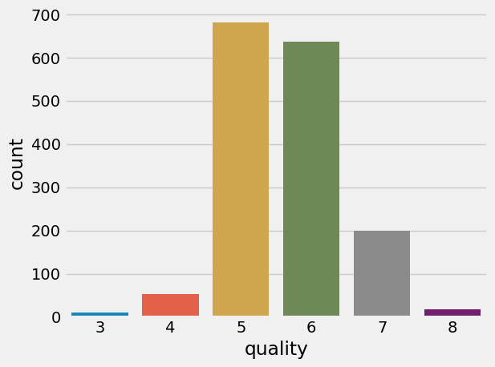

```python
sns.countplot(df, x="quality")
plt.tight_layout()
plt.show()
```

### Transformar la variable objetivo a 3 calidades (baja, media y alta)

#### Agrupar calidad en tres categorias: low, mid y high

```python
bins = [3,5,7,9] # Definimos los bins que separan los datos
bin_labels = ["low", "med", "high"] # Los nombres que recibiran
bin_labels_ord = [-1, 0, 1]
df["quality_cat"] = pd.cut(df["quality"], bins=bins, labels=bin_labels, right=False)
df["quality_ord"] = pd.cut(df["quality"], bins=bins, labels=bin_labels_ord, right=False)
df.groupby("quality", group_keys=False).apply(lambda x: x.sample(1))
```

|  | fixed acidity | volatile acidity | citric acid | residual sugar | chlorides | free sulfur dioxide | total sulfur dioxide | density | pH | sulphates | alcohol | quality | quality_cat | quality_ord |
| --- | --- | --- | --- | --- | --- | --- | --- | --- | --- | --- | --- | --- | --- | --- |
| 690 | 7.4 | 1.185 | 0.00 | 4.25 | 0.097 | 5.0 | 14.0 | 0.99660 | 3.63 | 0.54 | 10.7 | 3 | low | -1 |
| 79 | 8.3 | 0.625 | 0.20 | 1.50 | 0.080 | 27.0 | 119.0 | 0.99720 | 3.16 | 1.12 | 9.1 | 4 | low | -1 |
| 1225 | 9.2 | 0.460 | 0.23 | 2.60 | 0.091 | 18.0 | 77.0 | 0.99922 | 3.15 | 0.51 | 9.4 | 5 | med | 0 |
| 1106 | 8.2 | 0.230 | 0.42 | 1.90 | 0.069 | 9.0 | 17.0 | 0.99376 | 3.21 | 0.54 | 12.3 | 6 | med | 0 |
| 1067 | 11.1 | 0.310 | 0.53 | 2.20 | 0.060 | 3.0 | 10.0 | 0.99572 | 3.02 | 0.83 | 10.9 | 7 | high | 1 |
| 588 | 5.0 | 0.420 | 0.24 | 2.00 | 0.060 | 19.0 | 50.0 | 0.99170 | 3.72 | 0.74 | 14.0 | 8 | high | 1 |

Para mitigar esta disparidad y mejorar la capacidad de generalización de nuestro modelo, optamos por crear tres nuevas categorías ordinales:

| quality | quality_cat | quality_ord |
| --- | --- | --- |
| 3 | low | -1 |
| 4 | low | -1 |
| 5 | med | 0 |
| 6 | med | 0 |
| 7 | high | 1 |
| 8 | high | 1 |

#### Boxplots de la variable objetivo: Quality

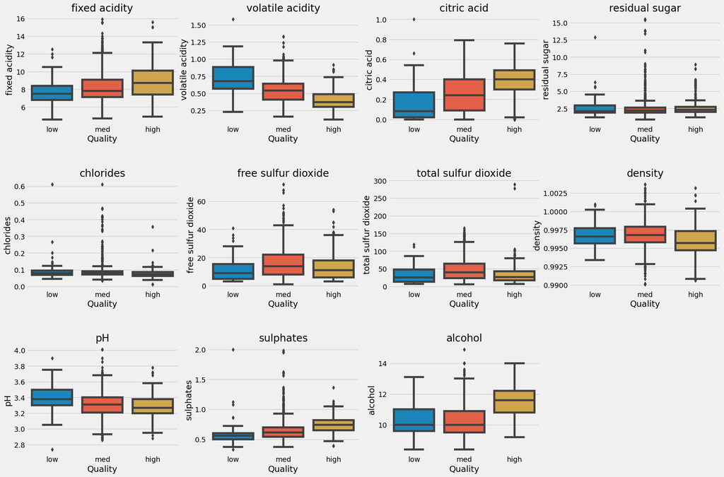

```python
fig, axes = plt.subplots(3, 4, figsize=(22, 15))
fig.subplots_adjust(hspace=0.5)
for i, column in enumerate(columns_to_plot):
    row = i // 4
    col = i % 4
    sns.boxplot(data=df, x='quality_cat', y=column, ax=axes[row, col])
    axes[row, col].set_title(column)
    axes[row, col].set_xlabel('Quality')
    axes[row, col].set_ylabel(column)
for i in range(len(columns_to_plot), 3 * 4):
    row = i // 4
    col = i % 4
    fig.delaxes(axes[row, col])
plt.show()
```

### 2.4 Identificación de relaciones:

- Identificación de posibles correlaciones o relaciones entre las características fisicoquímicas y la calidad del vino
- Información crucial para seleccionar las características más relevantes en etapas posteriores del proyecto

#### Matriz de correlación con las características originales

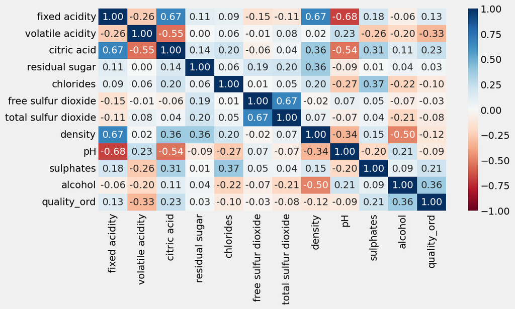

```python
plt.figure(figsize = (10,5)) #cambiamos la variable quality_ord a int para calcular correlacion
df['quality_ord'] = df['quality_ord'].astype('int')
corr_matrix = df.drop(columns=["quality_cat","quality"]).corr()
sns.heatmap(corr_matrix, annot=True,cmap='RdBu', fmt = '.2f', vmin=-1, vmax=1)
```

## 3. Preparación de los datos

- En este paso, el principal objetivo es limpiar y preparar los datos.
- creación de atributos adicionales según sea necesario, que se utilizarán para el modelado.

### 3.1 Limpieza de datos:

- Identificación de posibles relaciones entre las características fisicoquímicas y la calidad del vino
- Información crucial para seleccionar las características más relevantes en etapas posteriores del proyecto

```python
# Valor absoluto de la correlación de las variable independientes con la variable dependiente

quality_corr = corr_matrix.loc["quality_ord"].abs().sort_values()
quality_corr
```

```
free sulfur dioxide     0.025075
residual sugar          0.030153
total sulfur dioxide    0.081960
pH                      0.093946
chlorides               0.098829
density                 0.123566
fixed acidity           0.125886
sulphates               0.205409
citric acid             0.228930
volatile acidity        0.333816
alcohol                 0.361363
quality_ord             1.000000
Name: quality_ord, dtype: float64
```

#### Se procede a detectar y eliminar las variables poco correlacionadasa la variable dependiente, una correlación < 0.10

```python
# Detección de variables poco relacionadas a la variable dependiente
CORR_THRESH = 0.10 # Una correlación menor se considera muy baja
low_corr_vars = quality_corr[quality_corr < CORR_THRESH]
low_corr_vars
```

```
free sulfur dioxide     0.025075
residual sugar          0.030153
total sulfur dioxide    0.081960
pH                      0.093946
chlorides               0.098829
Name: quality_ord, dtype: float64
```

```python
low_corr_names = low_corr_vars.index.tolist()
low_corr_names # Esta lista contiene las columnas se eliminan
```

```
['free sulfur dioxide',
 'residual sugar',
 'total sulfur dioxide',
 'pH',
 'chlorides']
```

```python
# Creación del DataFrame con las variables independientes de alta correlación
df_trans = df.drop(columns=low_corr_names)
df_trans.head()
```

|  | fixed acidity | volatile acidity | citric acid | density | sulphates | alcohol | quality | quality_cat | quality_ord |
| --- | --- | --- | --- | --- | --- | --- | --- | --- | --- |
| 0 | 7.4 | 0.70 | 0.00 | 0.9978 | 0.56 | 9.4 | 5 | med | 0 |
| 1 | 7.8 | 0.88 | 0.00 | 0.9968 | 0.68 | 9.8 | 5 | med | 0 |
| 2 | 7.8 | 0.76 | 0.04 | 0.9970 | 0.65 | 9.8 | 5 | med | 0 |
| 3 | 11.2 | 0.28 | 0.56 | 0.9980 | 0.58 | 9.8 | 6 | med | 0 |
| 4 | 7.4 | 0.70 | 0.00 | 0.9978 | 0.56 | 9.4 | 5 | med | 0 |

#### Heatmap de la matriz reducida de alta correlación

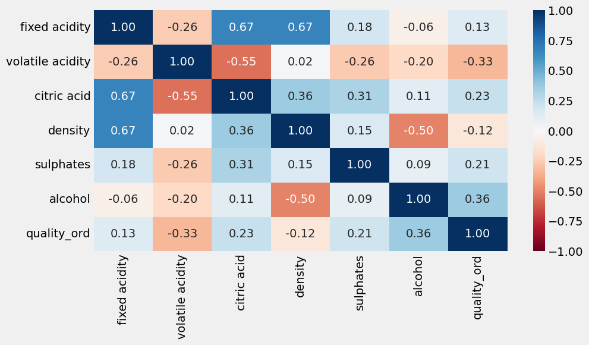

```python
# Heatmap de la matriz de alta correlación
plt.figure(figsize = (10,5))
trans_corr_matrix = df_trans.drop(columns=["quality_cat","quality"]).corr()
sns.heatmap(trans_corr_matrix, annot=True,cmap='RdBu', fmt = '.2f', vmin=-1, vmax=1)
```

### 3.2 Detección de outliers:

- Identificar observaciones que son significativamente diferentes o inusuales en comparación con el resto de los datos.

#### Mediante el método de *Local Outlier Factor* de *Sklearn*

```python
clf = LocalOutlierFactor(n_neighbors=20)
X = df_trans.drop(columns=['quality', 'quality_cat', 'quality_ord'])
estimado_LOF = clf.fit_predict(X)
df_clean = df_trans[~(estimado_LOF==-1)]
print(f"Cantidad de outliers: {abs(estimado_LOF[estimado_LOF==-1].sum())}")
```

```
Cantidad de outliers: 56
```

#### Comparación de variables antes (Rojo) y despues (Azul) de la detección de Outlier

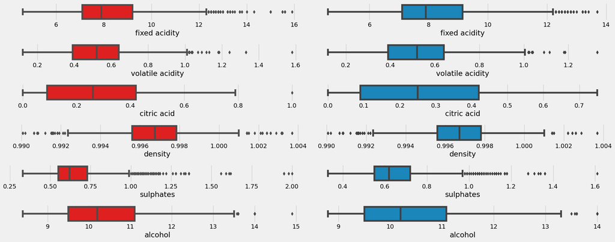

```python
columns_to_compare = df_trans.columns.drop(['quality', 'quality_cat', 'quality_ord'])
n_plots = len(columns_to_compare)
fig, axes = plt.subplots(n_plots, 2, figsize=(20, 8))
for i, column in enumerate(columns_to_compare):
    sns.boxplot(x=df_trans[column], ax=axes[i, 0], color='red')
    sns.boxplot(x=df_clean[column], ax=axes[i, 1])
plt.tight_layout()
plt.show()
```

### Comparar ambos dataset en columnas y filas

- Quitando outliers y variables con baja correlación

```python
print(f"Forma de los datos originales: {df.shape}")
print(f"Forma de los datos transformados: {df_clean.shape}")
```

```
Forma de los datos originales: (1599, 14)
Forma de los datos transformados: (1543, 9)
```

## 4. Modelado

- En este paso, se construyen los modelos predictivos utilizando los datos preparados en las fases anteriores
- creación de atributos adicionales según sea necesario, que se utilizarán para el modelado.

### En nuestro caso hemos seleccionado el modelo de Random Forest

Este método es una técnica de ensamblaje que combina múltiples árboles de decisión independientes. Cada árbol es entrenado en un subconjunto aleatorio de los datos y utiliza una selección aleatoria de características. Cuando se realiza una predicción, cada árbol emite su propia clasificación y, finalmente, la clase más votada se convierte en la predicción del modelo. Esta estrategia de voto mayoritario y aleatorización en la selección de datos y características mejora significativamente la precisión y la capacidad de generalización del modelo.

[figure not shown]

```python
# definimos la función que toma datos y devuelve los mejores parámetros
def search_params(X, y, random=False, n_iter=100):
    # Definir el pipeline con los escaladores y clasificadores
    pipeline = Pipeline([
        ('scaler', None),  # El escalador será seleccionado automáticamente por GridSearchCV
        ('classifier', None),  # El clasificador será seleccionado automáticamente por GridSearchCV
    ])

    # Definir los parámetros para GridSearchCV

    # NOTA: para los parámetros del clasificador se utiliza el prefijo classifier__ por convención
    # para indicar que ese parámetro es para el valor de la clave 'classifier'
    parameters = [
        # Probar distintos escaladores con distintos parámetros de RandomForestClassifier
        {
            'scaler': [Normalizer(), StandardScaler(), MinMaxScaler()],
            'classifier': [RandomForestClassifier()],
            # Parametros del clasificador
            'classifier__n_jobs': [-1],
            'classifier__n_estimators': np.linspace(50, 500, 10).astype(int),
            'classifier__max_features': ['sqrt', 'log2'],
            'classifier__max_depth': np.linspace(5, 30, 6).astype(int),
            'classifier__criterion': ['gini', 'entropy', 'log_loss'],
        },

        # Probar distintos escaladores con distintos parámetros de SVC
        {
            'scaler': [Normalizer(), StandardScaler(), MinMaxScaler()],
            'classifier': [SVC()],
            # Parámetros del clasificador
            'classifier__probability': [True],
            'classifier__C': np.linspace(1, 100, 10),
            'classifier__kernel': ['linear', 'poly', 'rbf', 'sigmoid'],
            'classifier__gamma': ['scale', 'auto'],
        },

        # Probar distintos escaladores con distintos parámetros de KNeighborsClassifier
        {
            'scaler': [Normalizer(), StandardScaler(), MinMaxScaler()],
            'classifier': [KNeighborsClassifier()],
            # Parámetros del clasificador
            'classifier__n_neighbors': np.linspace(5, 25, 5).astype(int),
            'classifier__weights': ['uniform', 'distance'],
        },
    ]

    print(f"Los parámetros para probar en nuestras pipelines son:")
    pprint(parameters)

    # Creamos un pipeline con parámetros por defecto (serán sustituidos)
    pipeline = Pipeline([
        ('scaler', None),
        ('classifier', None)
    ])

    if random:
        search = RandomizedSearchCV(pipeline, parameters, cv=5, n_jobs=-1, scoring='f1_weighted', verbose=1, n_iter=n_iter)
    else:
        search = GridSearchCV(pipeline, parameters, cv=5, n_jobs=-1, scoring='f1_weighted', verbose=1)

    search.fit(X, y)

    # Obtener los mejores hiperparámetros y el mejor modelo
    best_params = search.best_params_
    best_model = search.best_estimator_

    print(f"Los mejores parámetros de la busqueda: {best_params}")
    print(f"El mejor modelo de la busqueda: {best_model}")

    return best_model, best_params
```

### Primer entrenamiento: usando todas las columnas

El primer entrenamiento lo llevaremos a cabo usando todas las columnas que venian originalmente en el DataFrame. La unica diferenciaes el cambio de la variable objetivo pues utilizaremos como variable objetivo quality_ord.

```python
X = df.drop(columns=["quality", "quality_cat", "quality_ord"]).to_numpy() # Quitamos las variables de la calidad
y = df["quality_ord"].to_numpy()  # Nos quedamos solo con la caliad (ordinal: -1, 0, 1)

X.shape, y.shape
```

```
((1599, 11), (1599,))
```

### Dividir en entrenamiento y prueba

```python
n_folds = 5
test_size = 0.10
X_train, X_test, y_train, y_test = train_test_split(X, y, test_size=test_size, stratify=y)
print(f"Se usarán {X_train.shape[0]} entradas para el entrenamiento del modelo usando K-Fold ({n_folds} folds)")
print(f"Se reservó un {int(test_size*100)}% de los datos ({X_test.shape[0]}) para validar al final del entrenamiento.")
```

```
Se usarán 1439 entradas para el entrenamiento del modelo usando K-Fold (5 folds)
Se reservó un 10% de los datos (160) para validar al final del entrenamiento.
```

### Entrenamiento 1

```python
best_model, best_params = search_params(X_train, y_train, random=False)
```

```
Los parámetros para probar en nuestras pipelines son:
[{'classifier': [RandomForestClassifier()],
  'classifier__criterion': ['gini', 'entropy', 'log_loss'],
  'classifier__max_depth': array([ 5, 10, 15, 20, 25, 30]),
  'classifier__max_features': ['sqrt', 'log2'],
  'classifier__n_estimators': array([ 50, 100, 150, 200, 250, 300, 350, 400, 450, 500]),
  'classifier__n_jobs': [-1],
  'scaler': [Normalizer(), StandardScaler(), MinMaxScaler()]},
 {'classifier': [SVC()],
  'classifier__C': array([  1.,  12.,  23.,  34.,  45.,  56.,  67.,  78.,  89., 100.]),
  'classifier__gamma': ['scale', 'auto'],
  'classifier__kernel': ['linear', 'poly', 'rbf', 'sigmoid'],
  'classifier__probability': [True],
  'scaler': [Normalizer(), StandardScaler(), MinMaxScaler()]},
 {'classifier': [KNeighborsClassifier()],
  'classifier__n_neighbors': array([ 5, 10, 15, 20, 25]),
  'classifier__weights': ['uniform', 'distance'],
  'scaler': [Normalizer(), StandardScaler(), MinMaxScaler()]}]
Fitting 5 folds for each of 1350 candidates, totalling 6750 fits
Los mejores parámetros de la busqueda: {'classifier': RandomForestClassifier(max_depth=15, max_features='log2', n_estimators=200,
                       n_jobs=-1), 'classifier__criterion': 'gini', 'classifier__max_depth': 15, 'classifier__max_features': 'log2', 'classifier__n_estimators': 200, 'classifier__n_jobs': -1, 'scaler': StandardScaler()}
El mejor modelo de la busqueda: Pipeline(steps=[('scaler', StandardScaler()),
                ('classifier',
                 RandomForestClassifier(max_depth=15, max_features='log2',
                                        n_estimators=200, n_jobs=-1))])
```

```python
best_model.fit(X_train, y_train)
```

```
Pipeline(steps=[('scaler', StandardScaler()),
                ('classifier',
                 RandomForestClassifier(max_depth=15, max_features='log2',
                                        n_estimators=200, n_jobs=-1))])
```

```python
print('Training set score: ' + str(best_model.score(X_train, y_train)))
print('Test set score: ' + str(best_model.score(X_test, y_test)))
```

```
Training set score: 0.9972202918693537
Test set score: 0.86875
```

```python
X_test_df = pd.DataFrame(X_test, columns = df.drop(columns=["quality", "quality_cat", "quality_ord"]).columns)
y_test_df = pd.Series(y_test)

print('Training set score -1: ' + str(best_model.score(X_test_df.loc[y_test_df[y_test_df == -1].index].to_numpy(), y_test_df[y_test_df == -1])))
print('Training set score 0: ' + str(best_model.score(X_test_df.loc[y_test_df[y_test_df == 0].index].to_numpy(), y_test_df[y_test_df == 0])))
print('Training set score 1: ' + str(best_model.score(X_test_df.loc[y_test_df[y_test_df == 1].index].to_numpy(), y_test_df[y_test_df == 1])))
```

```
Training set score -1: 0.0
Training set score 0: 0.9772727272727273
Training set score 1: 0.45454545454545453
```

[figure not shown]

```python
confusion_mat = confusion_matrix(y_test, y_hat)

# Crear un mapa de calor para visualizar la matriz de confusión
plt.figure(figsize=(6, 4))
sns.heatmap(confusion_mat, annot=True, fmt='d', cmap='viridis', cbar=True,
            xticklabels=[1, 0, -1], yticklabels=[-1, 0, 1])
plt.xlabel('Predicciones')
plt.ylabel('Valores reales')
plt.title('Confusion Matrix')
plt.show()
```

### Segundo entrenamiento: filtrando las columnas con baja corelación

```python
X = df_clean.drop(columns=["quality", "quality_cat", "quality_ord"]).to_numpy() # Quitamos las variables de la calidad
y = df_clean["quality_ord"].to_numpy()  # Nos quedamos solo con la caliad (ordinal: -1, 0, 1)
X.shape, y.shape
```

```
((1543, 6), (1543,))
```

### Dividir en entrenamiento y prueba

```python
X_train, X_test, y_train, y_test = train_test_split(X, y, test_size=test_size, stratify=y)
print(f"Se usarán {X_train.shape[0]} entradas para el entrenamiento del modelo usando K-Fold ({n_folds} folds)")
print(f"Se reservó un {int(test_size*100)}% de los datos ({X_test.shape[0]}) para validar al final del entrenamiento.")
```

```
Se usarán 1388 entradas para el entrenamiento del modelo usando K-Fold (5 folds)
Se reservó un 10% de los datos (155) para validar al final del entrenamiento.
```

### Entrenamiento 2

Probando todas las combinaciones posibles

```python
best_model, best_params = search_params(X_train, y_train, random=False)
```

```
Los parámetros para probar en nuestras pipelines son:
[{'classifier': [RandomForestClassifier()],
  'classifier__criterion': ['gini', 'entropy', 'log_loss'],
  'classifier__max_depth': array([ 5, 10, 15, 20, 25, 30]),
  'classifier__max_features': ['sqrt', 'log2'],
  'classifier__n_estimators': array([ 50, 100, 150, 200, 250, 300, 350, 400, 450, 500]),
  'classifier__n_jobs': [-1],
  'scaler': [Normalizer(), StandardScaler(), MinMaxScaler()]},
 {'classifier': [SVC()],
  'classifier__C': array([  1.,  12.,  23.,  34.,  45.,  56.,  67.,  78.,  89., 100.]),
  'classifier__gamma': ['scale', 'auto'],
  'classifier__kernel': ['linear', 'poly', 'rbf', 'sigmoid'],
  'classifier__probability': [True],
  'scaler': [Normalizer(), StandardScaler(), MinMaxScaler()]},
 {'classifier': [KNeighborsClassifier()],
  'classifier__n_neighbors': array([ 5, 10, 15, 20, 25]),
  'classifier__weights': ['uniform', 'distance'],
  'scaler': [Normalizer(), StandardScaler(), MinMaxScaler()]}]
Fitting 5 folds for each of 1350 candidates, totalling 6750 fits
Los mejores parámetros de la busqueda: {'classifier': RandomForestClassifier(criterion='log_loss', max_depth=30, max_features='log2',
                       n_estimators=200, n_jobs=-1), 'classifier__criterion': 'log_loss', 'classifier__max_depth': 30, 'classifier__max_features': 'log2', 'classifier__n_estimators': 200, 'classifier__n_jobs': -1, 'scaler': Normalizer()}
El mejor modelo de la busqueda: Pipeline(steps=[('scaler', Normalizer()),
                ('classifier',
                 RandomForestClassifier(criterion='log_loss', max_depth=30,
                                        max_features='log2', n_estimators=200,
                                        n_jobs=-1))])
```

```python
print(best_model)
```

```
Pipeline(steps=[('scaler', Normalizer()),
                ('classifier',
                 RandomForestClassifier(criterion='log_loss', max_depth=30,
                                        max_features='log2', n_estimators=200,
                                        n_jobs=-1))])
```

```python
best_params
```

```
{'classifier': RandomForestClassifier(criterion='log_loss', max_depth=30, max_features='log2',
                        n_estimators=200, n_jobs=-1),
 'classifier__criterion': 'log_loss',
 'classifier__max_depth': 30,
 'classifier__max_features': 'log2',
 'classifier__n_estimators': 200,
 'classifier__n_jobs': -1,
 'scaler': Normalizer()}
```

```python
best_model.fit(X_train, y_train)
```

```
Pipeline(steps=[('scaler', Normalizer()),
                ('classifier',
                 RandomForestClassifier(criterion='log_loss', max_depth=30,
                                        max_features='log2', n_estimators=200,
                                        n_jobs=-1))])
```

```python
print('Training set score: ' + str(best_model.score(X_train, y_train)))
print('Test set score: ' + str(best_model.score(X_test, y_test)))
```

```
Training set score: 1.0
Test set score: 0.8387096774193549
```

[figure not shown]

```python
confusion_mat = confusion_matrix(y_test, y_hat)

# Crear un mapa de calor para visualizar la matriz de confusión
plt.figure(figsize=(6, 4))
sns.heatmap(confusion_mat, annot=True, fmt='d', cmap='viridis', cbar=True,
            xticklabels=[1, 0, -1], yticklabels=[-1, 0, 1])
plt.xlabel('Predicciones')
plt.ylabel('Valores reales')
plt.title('Confusion Matrix 2')
plt.show()
```

## 5. Evaluación

En esta sección, evaluaremos el desempeño de nuestro modelo de Random Forest en la tarea de predecir la calidad del vino tinto.

### Matriz de confusión

La cual se compone de elementos que nos ayudan a medir la capacidad del modelo para clasificar correctamente las muestras en diferentes categorías de calidad:

- Verdaderos positivos (VP)
- Verdaderos negativos (VN)
- Falsos positivos (FP)
- Falsos negativos (FN)

|  | Predicción -1 | Predicción 0 | Predicción 1 |
| --- | --- | --- | --- |
| Real -1 | 0 | 6 | 0 |
| Real 0 | 0 | 129 | 3 |
| Real 1 | 0 | 12 | 10 |

### Cálculo de Métricas

Los resultados se detallan en la siguiente tabla:

[output not shown]

- Precisión (P): Mide la proporción de predicciones positivas realizadas por el modelo que fueron realmente correctas.
- Sensibilidad (S): Mide la proporción de ejemplos positivos reales que el modelo predijo correctamente.
- Puntuación F1: Es una métrica que combina precisión y sensibilidad en un solo valor, permitiendo equilibrar la importancia de estas dos métricas.

Además, se calculó un promedio ponderado de estas métricas, que tiene en cuenta el desbalance existente en la cantidad de datos de cada categoría:

[output not shown]

## 6. Implementación

- En la fase de implantación, consideramos cómo nuestros resultados pueden ser aplicados en un contexto empresarial. A pesar de ser un proyecto académico, sus hallazgos pueden tener un impacto significativo en la industria del vino y en otros sectores relacionados.
- Las empresas y productores pueden utilizar modelos similares para evaluar y optimizar sus procesos, lo que puede resultar en vinos de mayor calidad y una mejor respuesta a las necesidades cambiantes del mercado.

## Referencias

- Caughlin, D. (2020). k-Fold Cross-Validation [Video]. YouTube. https://www.youtube.com/watch?app=desktop&v=kituDjzXwfE
- Cortez, P., Cerdeira, A., Almeida, F., Matos, T., & Reis, J. (2009). Modeling wine preferences by data mining from physicochemical properties. Decision Support Systems, 47(4), 547-553. https://doi.org/10.1016/j.dss.2009.05.016
- Laura-Ochoa, L. (2019). Evaluación de Algoritmos de Clasificación utilizando Validación Cruzada. Proceedings of the 17th LACCEI International Multi-Conference for Engineering, Education, and Technology: “Industry, Innovation, and Infrastructure for Sustainable Cities and Communities”. The 17th LACCEI International Multi-Conference for Engineering, Education, and Technology: “Industry, Innovation, and Infrastructure for Sustainable Cities and Communities”. https://doi.org/10.18687/LACCEI2019.1.1.471
- Puckette, M. (2019). Beginner’s Guide To Vinho Verde Wine. Wine Folly. https://winefolly.com/deep-dive/vinho-verde-the-perfect-poolside-wine-from-portugal/
- Parmar, A., Katariya, R., & Patel, V. (2019). A Review on Random Forest: An Ensemble Classifier. En J. Hemanth, X. Fernando, P. Lafata, & Z. Baig (Eds.), International Conference on Intelligent Data Communication Technologies and Internet of Things (ICICI) 2018 (Vol. 26, pp. 758-763). Springer International Publishing. https://doi.org/10.1007/978-3-030-03146-6_86
- Plotnikova, V., Dumas, M., & Milani, F. P. (2022). Applying the CRISP-DM data mining process in the financial services industry: Elicitation of adaptation requirements. Data & Knowledge Engineering, 139, 102013. https://doi.org/10.1016/j.datak.2022.102013
- Schröer, C., Kruse, F., & Gómez, J. M. (2021). A Systematic Literature Review on Applying CRISP-DM Process Model. Procedia Computer Science, 181, 526-534. https://doi.org/10.1016/j.procs.2021.01.199
- Shen, Z. (2020). 3 min de Machine Learning: Cross Vaildation. Zitao's Web. https://zitaoshen.rbind.io/project/machine_learning/machine-learning-101-cross-vaildation/